# 02_on_separe_les_touristes

C.R.

12/03/2020

# Sur la base des nuitées

On doit pouvoir separer les touristes des travailleurs - entre saisonnalité annuelle et tendance - entre semaine et WE (travailleur / maison secondaire ) - entre saisonalité trimestrielle (ski / plage)

## modele naif

Les travailleurs ne travaillent pas pendant les vacances (…), donc le mieux à faire est qu’on enleve la moyenne des deplacements hors vacances scolaire à la courbe de nuitées.

```r
vacances_tsbl <- vacances_tsbl() %>%
  mutate(vacances = as.numeric(vacances) * max(nuitees_tsbl()$nuitees , na.rm = TRUE))
# avoid the 13 errors (1 unique) encountered for STL(nuitees ~ season(window = Inf))
# [13] STL decomposition does not support series with missing values.
nuitees_ts_filled <- nuitees_td %>%
  as_tsibble(index= date, key=dep) %>%
  group_by_key() %>%
  fill_gaps() %>%
  ungroup %>%
  tidyr::fill(nuitees, dep, .direction = "down")
```

# Les differences de saisonnalité sont elles réelles ?

On constate visuellement une faible saisonnalité sur la courbe du dep_31. Mais est-ce confirmé par le calcul, et est-ce le cas pour d’autres departements ?

```r
nuitees_stlf <-nuitee_ts %>%  features(nuitees, feat_stl)
nuitees_stlf %>% arrange(desc(trend_strength))
```

```
## # A tibble: 13 x 10
##    dep   trend_strength seasonal_streng… seasonal_peak_w… seasonal_trough…
##    <fct>          <dbl>            <dbl>            <dbl>            <dbl>
##  1 66             0.984            0.404                6                0
##  2 46             0.981            0.513                6                0
##  3 34             0.981            0.480                6                0
##  4 12             0.979            0.611                6                0
##  5 48             0.978            0.503                6                0
##  6 11             0.977            0.371                6                0
##  7 30             0.975            0.496                6                0
##  8 32             0.961            0.504                6                0
##  9 09             0.959            0.422                6                0
## 10 81             0.949            0.542                6                0
## 11 82             0.939            0.486                6                0
## 12 65             0.919            0.341                6                0
## 13 31             0.796            0.437                6                0
## # … with 5 more variables: spikiness <dbl>, linearity <dbl>, curvature <dbl>,
## #   stl_e_acf1 <dbl>, stl_e_acf10 <dbl>
```

```r
nuitees_stlf %>% arrange(seasonal_peak_week)
```

```
## # A tibble: 13 x 10
##    dep   trend_strength seasonal_streng… seasonal_peak_w… seasonal_trough…
##    <fct>          <dbl>            <dbl>            <dbl>            <dbl>
##  1 09             0.959            0.422                6                0
##  2 11             0.977            0.371                6                0
##  3 12             0.979            0.611                6                0
##  4 30             0.975            0.496                6                0
##  5 31             0.796            0.437                6                0
##  6 32             0.961            0.504                6                0
##  7 34             0.981            0.480                6                0
##  8 46             0.981            0.513                6                0
##  9 48             0.978            0.503                6                0
## 10 65             0.919            0.341                6                0
## 11 66             0.984            0.404                6                0
## 12 81             0.949            0.542                6                0
## 13 82             0.939            0.486                6                0
## # … with 5 more variables: spikiness <dbl>, linearity <dbl>, curvature <dbl>,
## #   stl_e_acf1 <dbl>, stl_e_acf10 <dbl>
```

Oumpf, personne n’aurait envie de lire des tableaux aussi absconts, faisons donc un plot !

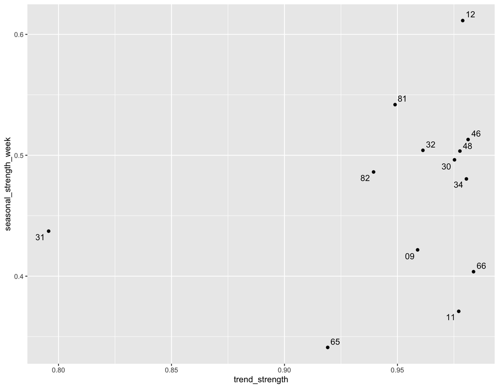

```r
nuitees_stlf %>%
  ggplot(aes(x = trend_strength, y = seasonal_strength_week, label=dep)) +
  geom_point()+
  geom_text_repel()
```

Ah ! Oui ! la Haute Garonne se distingue bien largement de ses voisins d’Occitanie. On creusera par origine pour decouvrir d’ou viennent les voyageurs qui contribuent à ça.

# Regression a saisonnalité hebdromadaire

Voyons dans les faits ce qu’on mesure par une visualisation de la décomposition :

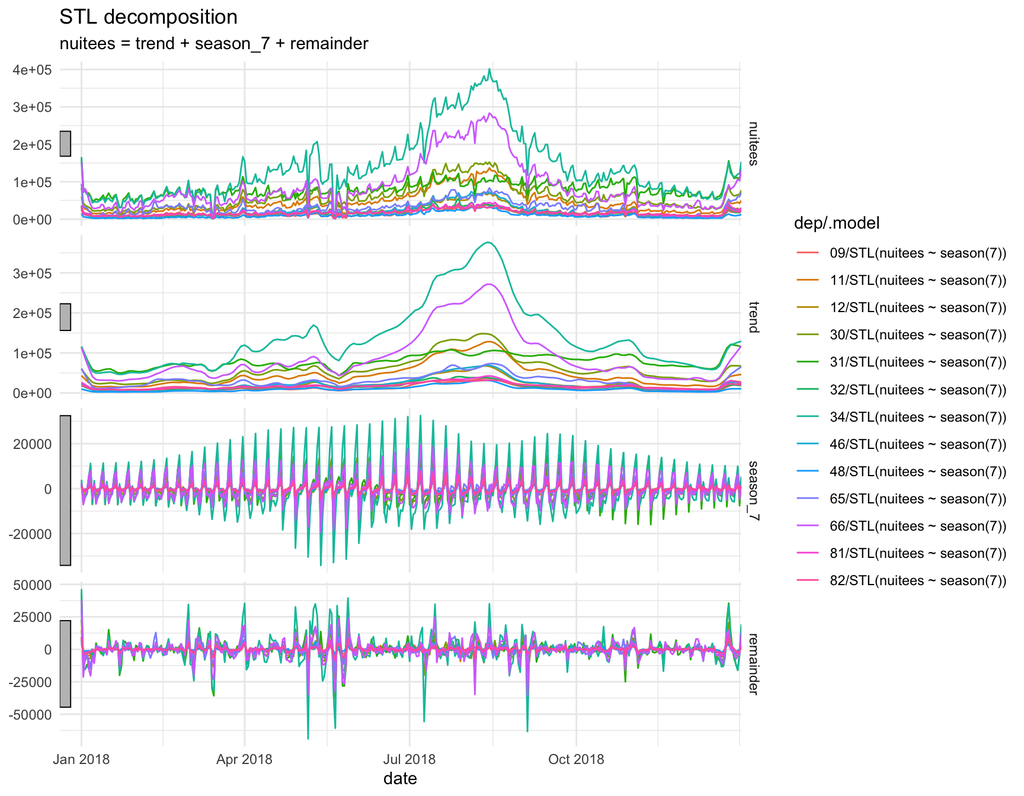

C’est très curieux, le distingo s’établit à l’oeil sur la tendance, pas sur la composante hebdomadaire.

Pour pouvoir dire “Cette serie c’est -majoritairement- des travailleurs” Il faudrait avoir un pattern du genre celui-ci

[figure not shown]

i.e. avec une influence négative des weekends, qund les usages des déplacements sont clairement séparés.. Ici, qqsoit la série, c’est un mélange…

```
## Plot variable not specified, automatically selected `.vars = season_7`
```

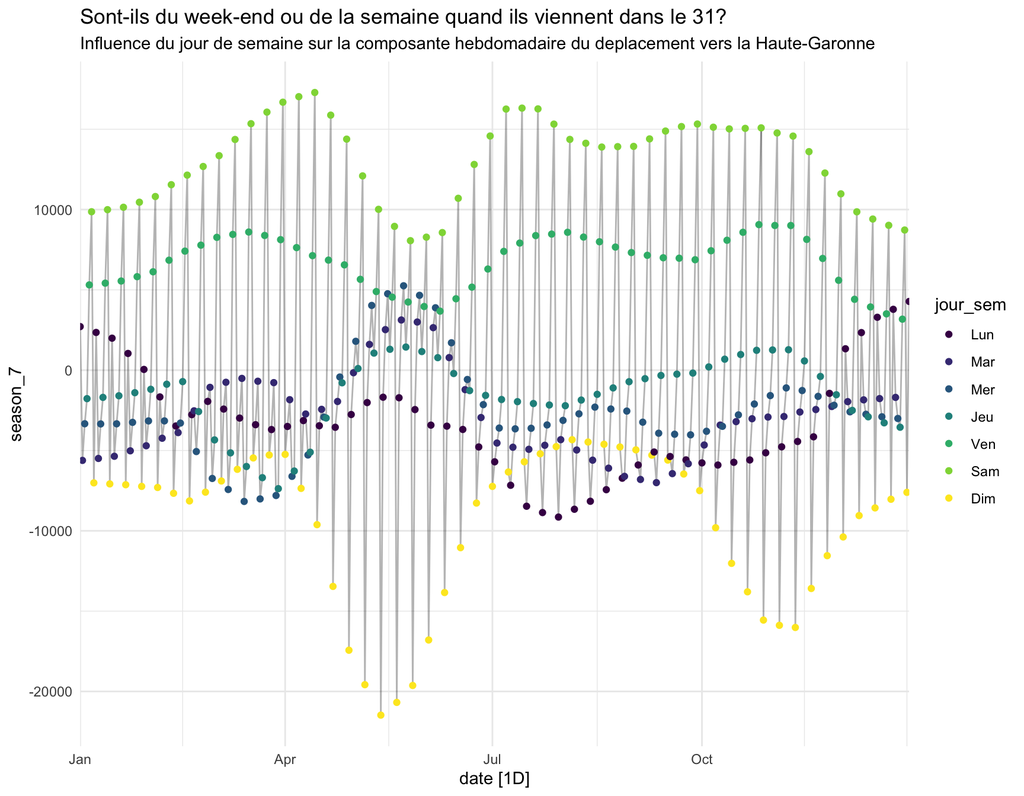

```
## Plot variable not specified, automatically selected `.vars = season_7`
```

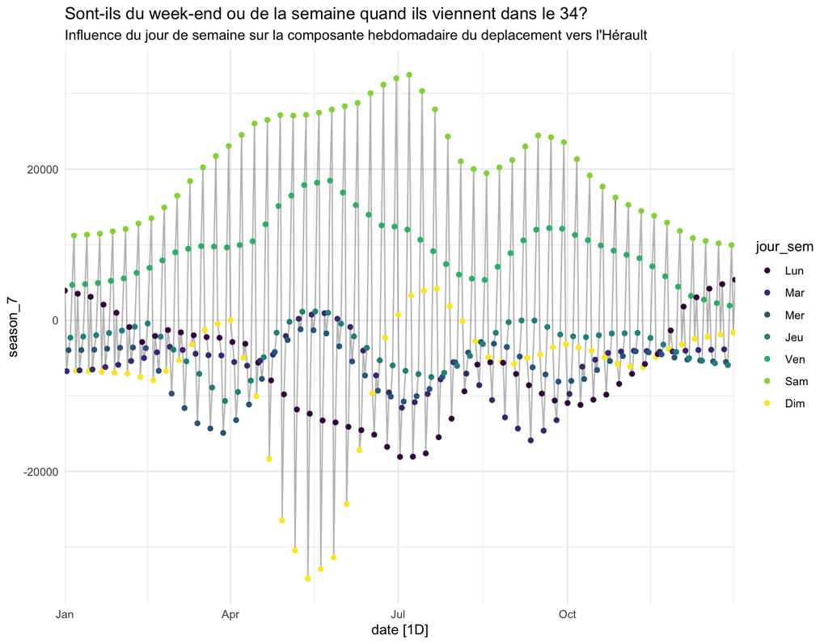

On voit très bien qu’il y a quelque chose à dire ici ! On a meme envie de balancer des small multiples sur chaque departement ! Ça donne meme envie de le faire sur chaque département d’origine, meme si ça risque de faire un pâté…

## regression a saisonnalité mensuelle

Relançons la meme analyse sur la tendance seulement i.e. sur le dataset capacite

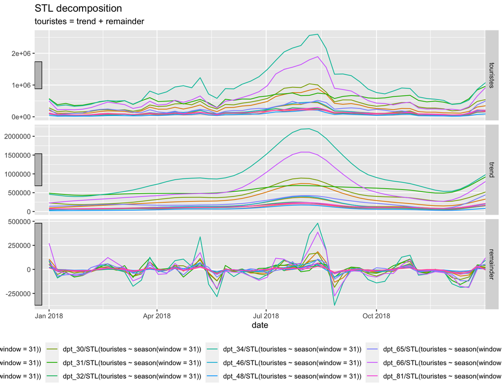

```r
hebergement_stlmod <-hebergement_ts %>%
  model(STL(touristes ~ season(window = 31)))
components(hebergement_stlmod) %>% autoplot +
  theme(legend.position = "bottom") +
  scale_x_date(expand = c(0,0))
```

# origines.xlsx

## regression saisonniere annuelle par departement source et origine

```r
# TODO errors (2 unique) encountered for ets
#[936] .data contains implicit gaps in time. You should check your data and convert implicit gaps into explicit missing values using `tsibble::fill_gaps()` if required.
origines_ts <- origines_ts %>%
  group_by_key() %>%
  fill_gaps() %>%
  tidyr::fill(volume, .direction = "down")

origine_ts_mean <- origines_ts %>% as_tibble %>% group_by(dep_org, dep) %>% summarize_at("volume", mean, na.rm=T)
```

Le package `feats` doit nous donner naturellement des viz de la mort:

```r
# origines_feats <-origines_ts %>% features(volume, feat_stl)
# TODO ajoutons l'importance des arrivees sur chacun des points pour en obtenir l'importance
# BUG les series ne sont pas assemblables ( pas d'ordonnancement commun sur les facteurs)
origines_feats <-bind_cols(
  origines_ts %>% features(volume, feat_stl, )%>% arrange(.by_group=T),
  origine_ts_mean %>% select(volume)
  )
```

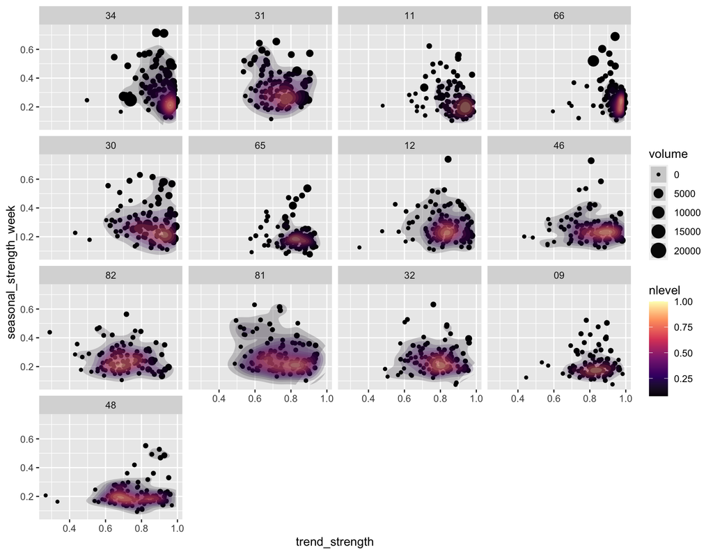

```r
# TODO consider volume in the stat_density_2d
origines_feats %>%
  ggplot(aes(x = trend_strength, y = seasonal_strength_week, size = volume) ) +
  geom_point() +
  stat_density_2d(aes(fill = after_stat(nlevel)), geom = "polygon", alpha=0.2) +
  facet_wrap(vars(dep)) +
  scale_fill_viridis_c(option = "A")
```

```r
# TODO turn it 3d with library(rayshader)
```

c’est vraiement beau, mais j’ai pas l’histoire a raconter avec…